# 🍕 Food Bank of the World 🌍 — Limpieza de Datos

## Descripción general

Es un conjunto de datos disponible en Kaggle que recopila información sobre la producción mundial de alimentos durante más de 60 años **(1961–2020)**. Incluye más de 2 millones de registros relacionados con cultivos, ganadería, uso de la tierra y población en 247+ países y territorios.

## Objetivo

El dataset busca ayudar a investigadores, analistas y científicos de datos a estudiar:

1. Producción agrícola mundial.
2. Seguridad alimentaria.
3. Uso eficiente de recursos naturales.
4. Impacto del crecimiento poblacional sobre la producción de alimentos.
5. Tendencias históricas de cultivos y ganadería.
6. Modelos predictivos de oferta alimentaria.

La inspiración surge de la preocupación por la crisis alimentaria mundial, agravada por factores como:

1. Conflictos internacionales (ej. guerra en Ucrania).
2. Problemas en cadenas de suministro.
3. Consecuencias económicas de la pandemia de COVID-19.
4. Incremento global de los precios de los alimentos.

# 🌾 PARTE 1 — crop1.csv

### Producción Agrícola Mundial

Contiene datos históricos de producción agrícola de más de 150 cultivos en más de 247 países, cubriendo más de seis décadas (1961–2020). Incluye indicadores como producción, rendimiento y área cosechada.

### Carga de datos

```python
import pandas as pd
import matplotlib.pyplot as plt
import seaborn as sns

# Ruta del archivo
ruta_crop = r"C:\Users\ESTUDIANTE\Downloads\dataset cliente1\crop1.csv"

# Cargar CSV
df_crop = pd.read_csv(ruta_crop)

# Mostrar las primeras 20 filas para identificar datos sucios
df_crop.head(20)
```

|  | Area | Item | Element | Year | Unit | Value |
| --- | --- | --- | --- | --- | --- | --- |
| 0 | Afghanistan | Almonds, with shell | Area harvested | 1975 | ha | 0.0 |
| 1 | Afghanistan | Almonds, with shell | Area harvested | 1976 | ha | 5900.0 |
| 2 | Afghanistan | Almonds, with shell | Area harvested | 1977 | ha | 6000.0 |
| 3 | Afghanistan | Almonds, with shell | Area harvested | 1978 | ha | 6000.0 |
| 4 | Afghanistan | Almonds, with shell | Area harvested | 1979 | ha | 6000.0 |
| 5 | Afghanistan | Almonds, with shell | Area harvested | 1980 | ha | 5800.0 |
| 6 | Afghanistan | Almonds, with shell | Area harvested | 1981 | ha | 5800.0 |
| 7 | Afghanistan | Almonds, with shell | Area harvested | 1982 | ha | 5800.0 |
| 8 | Afghanistan | Almonds, with shell | Area harvested | 1983 | ha | 5700.0 |
| 9 | Afghanistan | Almonds, with shell | Area harvested | 1984 | ha | 5700.0 |
| 10 | Afghanistan | Almonds, with shell | Area harvested | 1985 | ha | 5600.0 |
| 11 | Afghanistan | Almonds, with shell | Area harvested | 1986 | ha | 5500.0 |
| 12 | Afghanistan | Almonds, with shell | Area harvested | 1987 | ha | 5500.0 |
| 13 | Afghanistan | Almonds, with shell | Area harvested | 1988 | ha | 5400.0 |
| 14 | Afghanistan | Almonds, with shell | Area harvested | 1989 | ha | 5400.0 |
| 15 | Afghanistan | Almonds, with shell | Area harvested | 1990 | ha | 6037.0 |
| 16 | Afghanistan | Almonds, with shell | Area harvested | 1991 | ha | 5500.0 |
| 17 | Afghanistan | Almonds, with shell | Area harvested | 1992 | ha | 5500.0 |
| 18 | Afghanistan | Almonds, with shell | Area harvested | 1993 | ha | 5500.0 |
| 19 | Afghanistan | Almonds, with shell | Area harvested | 1994 | ha | 5500.0 |

### Revisión de estructura y valores nulos

- `df.info()` → Muestra la estructura del dataset, tipos de datos, cantidad de registros y valores no nulos por columna.
- `df.isnull().sum()` → Cuenta la cantidad de valores nulos (faltantes) existentes en cada columna del dataset.

```python
# Revisar estructura y tipos de datos
df_crop.info()
```

```
<class 'pandas.core.frame.DataFrame'>
RangeIndex: 1895975 entries, 0 to 1895974
Data columns (total 6 columns):
 #   Column   Dtype
---  ------   -----
 0   Area     object
 1   Item     object
 2   Element  object
 3   Year     int64
 4   Unit     object
 5   Value    float64
dtypes: float64(1), int64(1), object(4)
memory usage: 86.8+ MB
```

```python
# Contar valores nulos por columna
print(df_crop.isnull().sum())
```

```
Area            0
Item            0
Element         0
Year            0
Unit            0
Value      129500
dtype: int64
```

### Eliminamos filas con valores nulos en la columna Value

```python
# Eliminar filas con valores nulos en la columna Value
df_crop = df_crop.dropna(subset=['Value'])
```

```python
# Corroborar que se eliminaron
print(df_crop.isnull().sum())
```

```
Area       0
Item       0
Element    0
Year       0
Unit       0
Value      0
dtype: int64
```

### Revisamos y eliminamos registros duplicados

```python
# Contar duplicados antes de eliminar
print("Duplicados encontrados:", df_crop.duplicated().sum())
```

```
Duplicados encontrados: 0
```

```python
# Eliminar duplicados
df_crop = df_crop.drop_duplicates()
print("Duplicados eliminados. Registros restantes:", len(df_crop))
```

```
Duplicados eliminados. Registros restantes: 1766475
```

### Creamos una copia de trabajo

```python
# Copia del DataFrame limpio
df_crop1 = df_crop.copy()
df_crop1
```

|  | Area | Item | Element | Year | Unit | Value |
| --- | --- | --- | --- | --- | --- | --- |
| 0 | Afghanistan | Almonds, with shell | Area harvested | 1975 | ha | 0.0 |
| 1 | Afghanistan | Almonds, with shell | Area harvested | 1976 | ha | 5900.0 |
| 2 | Afghanistan | Almonds, with shell | Area harvested | 1977 | ha | 6000.0 |
| 3 | Afghanistan | Almonds, with shell | Area harvested | 1978 | ha | 6000.0 |
| 4 | Afghanistan | Almonds, with shell | Area harvested | 1979 | ha | 6000.0 |
| ... | ... | ... | ... | ... | ... | ... |
| 1895970 | Net Food Importing Developing Countries | Wheat | Production | 2016 | tonnes | 52845182.0 |
| 1895971 | Net Food Importing Developing Countries | Wheat | Production | 2017 | tonnes | 57099662.0 |
| 1895972 | Net Food Importing Developing Countries | Wheat | Production | 2018 | tonnes | 55571780.0 |
| 1895973 | Net Food Importing Developing Countries | Wheat | Production | 2019 | tonnes | 53903035.0 |
| 1895974 | Net Food Importing Developing Countries | Wheat | Production | 2020 | tonnes | 54159916.0 |

1766475 rows × 6 columns

```python
df_crop1.info()
```

```
<class 'pandas.core.frame.DataFrame'>
Index: 1766475 entries, 0 to 1895974
Data columns (total 6 columns):
 #   Column   Dtype
---  ------   -----
 0   Area     object
 1   Item     object
 2   Element  object
 3   Year     int64
 4   Unit     object
 5   Value    float64
dtypes: float64(1), int64(1), object(4)
memory usage: 94.3+ MB
```

```python
df_crop1.describe()
```

|  | Year | Value |
| --- | --- | --- |
| count | 1.766475e+06 | 1.766475e+06 |
| mean | 1.992853e+03 | 1.077275e+06 |
| std | 1.711515e+01 | 1.403138e+07 |
| min | 1.961000e+03 | 0.000000e+00 |
| 25% | 1.979000e+03 | 4.500000e+03 |
| 50% | 1.994000e+03 | 2.687500e+04 |
| 75% | 2.008000e+03 | 1.303910e+05 |
| max | 2.020000e+03 | 1.955308e+09 |

### Corregimos tipos de datos y limpiamos espacios en columnas de texto

```python
# Eliminar espacios extra en columnas de texto
df_crop1['Area']    = df_crop1['Area'].str.strip()
df_crop1['Item']    = df_crop1['Item'].str.strip()
df_crop1['Element'] = df_crop1['Element'].str.strip()

# Convertir Year a datetime
df_crop1['Year'] = pd.to_datetime(df_crop1['Year'], format='%Y')

# Asegurar que Value sea numérico
df_crop1['Value'] = pd.to_numeric(df_crop1['Value'], errors='coerce')

df_crop1.head()
```

|  | Area | Item | Element | Year | Unit | Value |
| --- | --- | --- | --- | --- | --- | --- |
| 0 | Afghanistan | Almonds, with shell | Area harvested | 1975-01-01 | ha | 0.0 |
| 1 | Afghanistan | Almonds, with shell | Area harvested | 1976-01-01 | ha | 5900.0 |
| 2 | Afghanistan | Almonds, with shell | Area harvested | 1977-01-01 | ha | 6000.0 |
| 3 | Afghanistan | Almonds, with shell | Area harvested | 1978-01-01 | ha | 6000.0 |
| 4 | Afghanistan | Almonds, with shell | Area harvested | 1979-01-01 | ha | 6000.0 |

### Obtenemos los valores únicos de la columna Element

```python
# Ver los indicadores únicos del dataset
valores_unicos_element = df_crop1['Element'].unique()
print(valores_unicos_element)
```

```
['Area harvested' 'Yield' 'Production']
```

### Validamos rangos lógicos — eliminamos valores negativos

```python
# Revisar rango de años
df_crop1['Year_int'] = df_crop1['Year'].dt.year
print("Rango de años:", df_crop1['Year_int'].min(), "→", df_crop1['Year_int'].max())

# Revisar valores negativos (no tienen sentido para producción/rendimiento)
print("Valores negativos en Value:", (df_crop1['Value'] < 0).sum())

# Eliminar negativos si existen
df_crop1 = df_crop1[df_crop1['Value'] >= 0]
print("Registros tras eliminar negativos:", len(df_crop1))
```

[output not shown]

### Eliminamos outliers con umbral en el percentil 99

```python
# Revisar estadísticas antes del filtro
df_crop1.describe()
```

|  | Year | Value | Year_int |
| --- | --- | --- | --- |
| count | 1766475 | 1.766475e+06 | 1.766475e+06 |
| mean | 1992-11-08 01:30:04.906381568 | 1.077275e+06 | 1.992853e+03 |
| min | 1961-01-01 00:00:00 | 0.000000e+00 | 1.961000e+03 |
| 25% | 1979-01-01 00:00:00 | 4.500000e+03 | 1.979000e+03 |
| 50% | 1994-01-01 00:00:00 | 2.687500e+04 | 1.994000e+03 |
| 75% | 2008-01-01 00:00:00 | 1.303910e+05 | 2.008000e+03 |
| max | 2020-01-01 00:00:00 | 1.955308e+09 | 2.020000e+03 |
| std | NaN | 1.403138e+07 | 1.711515e+01 |

```python
# Aplicar umbral en percentil 99 para eliminar outliers extremos
umbral_crop = df_crop1['Value'].quantile(0.99)
df_crop1 = df_crop1[df_crop1['Value'] < umbral_crop]

print("Umbral aplicado:", umbral_crop)
df_crop1.describe()
```

```
Umbral aplicado: 17589093.780000024
```

|  | Year | Value | Year_int |
| --- | --- | --- | --- |
| count | 1748810 | 1.748810e+06 | 1.748810e+06 |
| mean | 1992-10-29 15:59:25.498825216 | 3.389818e+05 | 1.992828e+03 |
| min | 1961-01-01 00:00:00 | 0.000000e+00 | 1.961000e+03 |
| 25% | 1978-01-01 00:00:00 | 4.400000e+03 | 1.978000e+03 |
| 50% | 1994-01-01 00:00:00 | 2.594600e+04 | 1.994000e+03 |
| 75% | 2008-01-01 00:00:00 | 1.245758e+05 | 2.008000e+03 |
| max | 2020-01-01 00:00:00 | 1.758839e+07 | 2.020000e+03 |
| std | NaN | 1.354676e+06 | 1.711420e+01 |

### Renombramos columnas al español

```python
# Mapeo de nombres al español
mapeo_element_crop = {
    'Area harvested': 'Área Cosechada',
    'Production':     'Producción',
    'Yield':          'Rendimiento'
}

df_crop1['Element'] = df_crop1['Element'].map(mapeo_element_crop).fillna(df_crop1['Element'])

# Renombrar columnas base
df_crop1 = df_crop1.rename(columns={
    'Area':    'País',
    'Item':    'Cultivo',
    'Element': 'Indicador',
    'Unit':    'Unidad',
    'Value':   'Valor'
})

# Eliminar columna auxiliar Year_int
df_crop1 = df_crop1.drop(columns=['Year_int'])

df_crop1.head()
```

|  | País | Cultivo | Indicador | Year | Unidad | Valor |
| --- | --- | --- | --- | --- | --- | --- |
| 0 | Afghanistan | Almonds, with shell | Área Cosechada | 1975-01-01 | ha | 0.0 |
| 1 | Afghanistan | Almonds, with shell | Área Cosechada | 1976-01-01 | ha | 5900.0 |
| 2 | Afghanistan | Almonds, with shell | Área Cosechada | 1977-01-01 | ha | 6000.0 |
| 3 | Afghanistan | Almonds, with shell | Área Cosechada | 1978-01-01 | ha | 6000.0 |
| 4 | Afghanistan | Almonds, with shell | Área Cosechada | 1979-01-01 | ha | 6000.0 |

### Separamos en dos DataFrames

```python
# DataFrame 1: columnas base de identificación
df_crop1a = df_crop1[['País', 'Cultivo', 'Indicador', 'Year', 'Unidad', 'Valor']].copy()

# DataFrame 2: tabla pivote por indicador
df_crop1b = df_crop1.pivot_table(
    index=['País', 'Cultivo', 'Year'],
    columns='Indicador',
    values='Valor',
    aggfunc='mean'
).reset_index()

print("df_crop1a shape:", df_crop1a.shape)
print("df_crop1b shape:", df_crop1b.shape)
df_crop1b.head()
```

```
df_crop1a shape: (1748810, 6)
df_crop1b shape: (607461, 6)
```

| Indicador | País | Cultivo | Year | Producción | Rendimiento | Área Cosechada |
| --- | --- | --- | --- | --- | --- | --- |
| 0 | Afghanistan | Almonds, with shell | 1975-01-01 | 0.0 | NaN | 0.0 |
| 1 | Afghanistan | Almonds, with shell | 1976-01-01 | 9800.0 | 16610.0 | 5900.0 |
| 2 | Afghanistan | Almonds, with shell | 1977-01-01 | 9000.0 | 15000.0 | 6000.0 |
| 3 | Afghanistan | Almonds, with shell | 1978-01-01 | 12000.0 | 20000.0 | 6000.0 |
| 4 | Afghanistan | Almonds, with shell | 1979-01-01 | 10500.0 | 17500.0 | 6000.0 |

# 📊 Visualización Global — crop1.csv

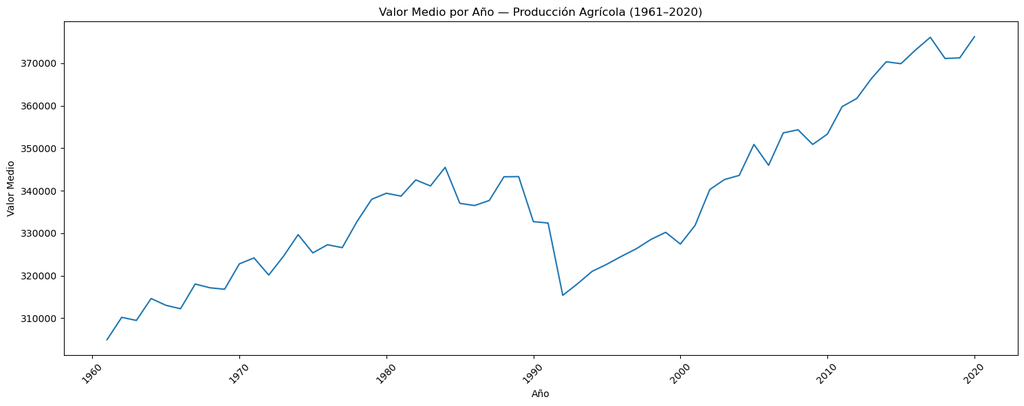

```python
# Valor medio por año
df_crop1a['Year_int'] = df_crop1a['Year'].dt.year
prod_por_año = df_crop1a.groupby('Year_int')['Valor'].mean().reset_index()

plt.figure(figsize=(15, 6))
sns.lineplot(data=prod_por_año, x='Year_int', y='Valor')
plt.title('Valor Medio por Año — Producción Agrícola (1961–2020)')
plt.xlabel('Año')
plt.ylabel('Valor Medio')
plt.xticks(rotation=45)
plt.tight_layout()
plt.show()
```

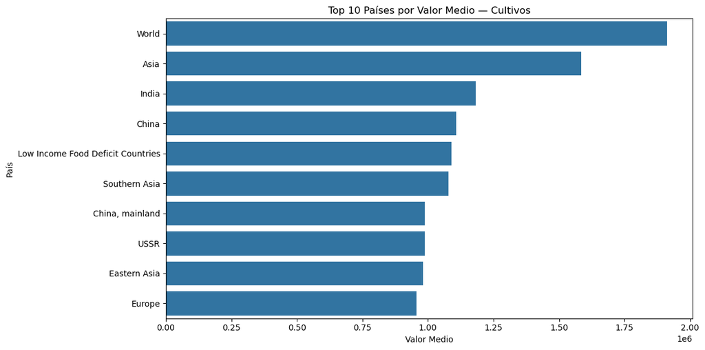

```python
# Top 10 países por valor medio
top_paises_crop = df_crop1a.groupby('País')['Valor'].mean().sort_values(ascending=False).head(10)

plt.figure(figsize=(12, 6))
sns.barplot(x=top_paises_crop.values, y=top_paises_crop.index)
plt.title('Top 10 Países por Valor Medio — Cultivos')
plt.xlabel('Valor Medio')
plt.ylabel('País')
plt.tight_layout()
plt.show()
```

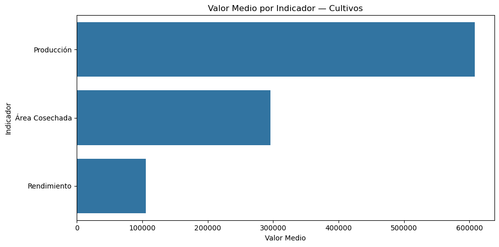

```python
# Valor medio por indicador
por_indicador_crop = df_crop1a.groupby('Indicador')['Valor'].mean().sort_values(ascending=False)

plt.figure(figsize=(10, 5))
sns.barplot(x=por_indicador_crop.values, y=por_indicador_crop.index)
plt.title('Valor Medio por Indicador — Cultivos')
plt.xlabel('Valor Medio')
plt.ylabel('Indicador')
plt.tight_layout()
plt.show()
```

# 🐄 PARTE 2 — live1.csv

### Carga de datos

```python
# Ruta del archivo
ruta_live = r"C:\Users\ESTUDIANTE\Downloads\dataset cliente1\live1.csv"

# Cargar CSV
df_live = pd.read_csv(ruta_live)

# Mostrar las primeras 20 filas para identificar datos sucios
df_live.head(20)
```

|  | Area | Item | Element | Year | Unit | Value |
| --- | --- | --- | --- | --- | --- | --- |
| 0 | Afghanistan | Asses | Stocks | 1961 | Head | 1300000.0 |
| 1 | Afghanistan | Asses | Stocks | 1962 | Head | 851850.0 |
| 2 | Afghanistan | Asses | Stocks | 1963 | Head | 1001112.0 |
| 3 | Afghanistan | Asses | Stocks | 1964 | Head | 1150000.0 |
| 4 | Afghanistan | Asses | Stocks | 1965 | Head | 1300000.0 |
| 5 | Afghanistan | Asses | Stocks | 1966 | Head | 1200000.0 |
| 6 | Afghanistan | Asses | Stocks | 1967 | Head | 1200000.0 |
| 7 | Afghanistan | Asses | Stocks | 1968 | Head | 1328000.0 |
| 8 | Afghanistan | Asses | Stocks | 1969 | Head | 1250000.0 |
| 9 | Afghanistan | Asses | Stocks | 1970 | Head | 1300000.0 |
| 10 | Afghanistan | Asses | Stocks | 1971 | Head | 1300000.0 |
| 11 | Afghanistan | Asses | Stocks | 1972 | Head | 1300000.0 |
| 12 | Afghanistan | Asses | Stocks | 1973 | Head | 1250000.0 |
| 13 | Afghanistan | Asses | Stocks | 1974 | Head | 1250000.0 |
| 14 | Afghanistan | Asses | Stocks | 1975 | Head | 1250000.0 |
| 15 | Afghanistan | Asses | Stocks | 1976 | Head | 1250000.0 |
| 16 | Afghanistan | Asses | Stocks | 1977 | Head | 1300000.0 |
| 17 | Afghanistan | Asses | Stocks | 1978 | Head | 1300000.0 |
| 18 | Afghanistan | Asses | Stocks | 1979 | Head | 1300000.0 |
| 19 | Afghanistan | Asses | Stocks | 1980 | Head | 1295000.0 |

### Revisión de estructura y valores nulos

- `df.info()` → Muestra la estructura del dataset, tipos de datos, cantidad de registros y valores no nulos por columna.
- `df.isnull().sum()` → Cuenta la cantidad de valores nulos (faltantes) existentes en cada columna del dataset.

```python
# Revisar estructura y tipos de datos
df_live.info()
```

```
<class 'pandas.core.frame.DataFrame'>
RangeIndex: 122458 entries, 0 to 122457
Data columns (total 6 columns):
 #   Column   Non-Null Count   Dtype
---  ------   --------------   -----
 0   Area     122458 non-null  object
 1   Item     122458 non-null  object
 2   Element  122458 non-null  object
 3   Year     122458 non-null  int64
 4   Unit     122458 non-null  object
 5   Value    120194 non-null  float64
dtypes: float64(1), int64(1), object(4)
memory usage: 5.6+ MB
```

Vemos que hay 122.458 registros totales con 120.194 valores no nulos, lo cual nos indica que hay **2.264 valores nulos** en la columna Value.

Corroboramos los datos faltantes con `df.isnull().sum()`

```python
df_live.isnull().sum()
```

```
Area          0
Item          0
Element       0
Year          0
Unit          0
Value      2264
dtype: int64
```

### Eliminamos filas con valores nulos en Value

```python
df_live = df_live.dropna(subset=['Value'])
```

```python
# Corroborar que se eliminaron
df_live.isnull().sum()
```

```
Area       0
Item       0
Element    0
Year       0
Unit       0
Value      0
dtype: int64
```

### Revisamos y eliminamos registros duplicados

```python
# Contar duplicados
print("Duplicados encontrados:", df_live.duplicated().sum())
```

```
Duplicados encontrados: 0
```

```python
# Eliminar duplicados
df_live = df_live.drop_duplicates()
print("Duplicados eliminados. Registros restantes:", len(df_live))
```

```
Duplicados eliminados. Registros restantes: 120194
```

### Creamos una copia de trabajo

```python
# Copia del DataFrame limpio
df_live1 = df_live.copy()
df_live1
```

|  | Area | Item | Element | Year | Unit | Value |
| --- | --- | --- | --- | --- | --- | --- |
| 0 | Afghanistan | Asses | Stocks | 1961 | Head | 1300000.0 |
| 1 | Afghanistan | Asses | Stocks | 1962 | Head | 851850.0 |
| 2 | Afghanistan | Asses | Stocks | 1963 | Head | 1001112.0 |
| 3 | Afghanistan | Asses | Stocks | 1964 | Head | 1150000.0 |
| 4 | Afghanistan | Asses | Stocks | 1965 | Head | 1300000.0 |
| ... | ... | ... | ... | ... | ... | ... |
| 122453 | Net Food Importing Developing Countries | Sheep | Stocks | 2016 | Head | 364166482.0 |
| 122454 | Net Food Importing Developing Countries | Sheep | Stocks | 2017 | Head | 371357850.0 |
| 122455 | Net Food Importing Developing Countries | Sheep | Stocks | 2018 | Head | 377303293.0 |
| 122456 | Net Food Importing Developing Countries | Sheep | Stocks | 2019 | Head | 397970957.0 |
| 122457 | Net Food Importing Developing Countries | Sheep | Stocks | 2020 | Head | 406555086.0 |

120194 rows × 6 columns

```python
df_live1.info()
```

```
<class 'pandas.core.frame.DataFrame'>
Index: 120194 entries, 0 to 122457
Data columns (total 6 columns):
 #   Column   Non-Null Count   Dtype
---  ------   --------------   -----
 0   Area     120194 non-null  object
 1   Item     120194 non-null  object
 2   Element  120194 non-null  object
 3   Year     120194 non-null  int64
 4   Unit     120194 non-null  object
 5   Value    120194 non-null  float64
dtypes: float64(1), int64(1), object(4)
memory usage: 6.4+ MB
```

```python
df_live1.describe()
```

|  | Year | Value |
| --- | --- | --- |
| count | 120194.000000 | 1.201940e+05 |
| mean | 1991.357314 | 1.035597e+07 |
| std | 17.262471 | 5.869386e+07 |
| min | 1961.000000 | 0.000000e+00 |
| 25% | 1976.000000 | 5.300000e+03 |
| 50% | 1992.000000 | 1.021735e+05 |
| 75% | 2006.000000 | 1.561571e+06 |
| max | 2020.000000 | 1.525939e+09 |

### Corregimos tipos de datos y limpiamos espacios en columnas de texto

```python
# Eliminar espacios extra en columnas de texto
df_live1['Area']    = df_live1['Area'].str.strip()
df_live1['Item']    = df_live1['Item'].str.strip()
df_live1['Element'] = df_live1['Element'].str.strip()

# Convertir Year a datetime
df_live1['Year'] = pd.to_datetime(df_live1['Year'], format='%Y')

# Asegurar que Value sea numérico
df_live1['Value'] = pd.to_numeric(df_live1['Value'], errors='coerce')

df_live1.head()
```

|  | Area | Item | Element | Year | Unit | Value |
| --- | --- | --- | --- | --- | --- | --- |
| 0 | Afghanistan | Asses | Stocks | 1961-01-01 | Head | 1300000.0 |
| 1 | Afghanistan | Asses | Stocks | 1962-01-01 | Head | 851850.0 |
| 2 | Afghanistan | Asses | Stocks | 1963-01-01 | Head | 1001112.0 |
| 3 | Afghanistan | Asses | Stocks | 1964-01-01 | Head | 1150000.0 |
| 4 | Afghanistan | Asses | Stocks | 1965-01-01 | Head | 1300000.0 |

### Obtenemos los valores únicos de la columna Element

```python
# Ver los indicadores únicos del dataset ganadero
valores_unicos_live = df_live1['Element'].unique()
print(valores_unicos_live)
```

```
['Stocks']
```

### Validamos rangos lógicos — eliminamos valores negativos

```python
# Revisar rango de años
df_live1['Year_int'] = df_live1['Year'].dt.year
print("Rango de años:", df_live1['Year_int'].min(), "→", df_live1['Year_int'].max())

# Revisar valores negativos
print("Valores negativos en Value:", (df_live1['Value'] < 0).sum())

# Eliminar negativos si existen
df_live1 = df_live1[df_live1['Value'] >= 0]
print("Registros tras eliminar negativos:", len(df_live1))
```

```
Rango de años: 1961 → 2020
Valores negativos en Value: 0
Registros tras eliminar negativos: 120194
```

### Eliminamos outliers con umbral en el percentil 99

```python
# Revisar estadísticas antes del filtro
df_live1.describe()
```

|  | Year | Value | Year_int |
| --- | --- | --- | --- |
| count | 120194 | 1.201940e+05 | 120194.000000 |
| mean | 1991-05-11 15:12:25.255170688 | 1.035597e+07 | 1991.357314 |
| min | 1961-01-01 00:00:00 | 0.000000e+00 | 1961.000000 |
| 25% | 1976-01-01 00:00:00 | 5.300000e+03 | 1976.000000 |
| 50% | 1992-01-01 00:00:00 | 1.021735e+05 | 1992.000000 |
| 75% | 2006-01-01 00:00:00 | 1.561571e+06 | 2006.000000 |
| max | 2020-01-01 00:00:00 | 1.525939e+09 | 2020.000000 |
| std | NaN | 5.869386e+07 | 17.262471 |

```python
# Aplicar umbral en percentil 99
umbral_live = df_live1['Value'].quantile(0.99)
df_live1 = df_live1[df_live1['Value'] < umbral_live]

print("Umbral aplicado:", umbral_live)
df_live1.describe()
```

```
Umbral aplicado: 229296069.2999996
```

|  | Year | Value | Year_int |
| --- | --- | --- | --- |
| count | 118992 | 1.189920e+05 | 118992.000000 |
| mean | 1991-04-25 23:23:11.206131456 | 5.676091e+06 | 1991.314441 |
| min | 1961-01-01 00:00:00 | 0.000000e+00 | 1961.000000 |
| 25% | 1976-01-01 00:00:00 | 5.150000e+03 | 1976.000000 |
| 50% | 1992-01-01 00:00:00 | 9.700000e+04 | 1992.000000 |
| 75% | 2006-01-01 00:00:00 | 1.438035e+06 | 2006.000000 |
| max | 2020-01-01 00:00:00 | 2.292923e+08 | 2020.000000 |
| std | NaN | 2.159487e+07 | 17.266050 |

### Renombramos columnas al español

```python
# Mapeo de indicadores al español
mapeo_element_live = {
    'Stocks':     'Existencias',
    'Production': 'Producción',
    'Yield':      'Rendimiento'
}

df_live1['Element'] = df_live1['Element'].map(mapeo_element_live).fillna(df_live1['Element'])

# Renombrar columnas base
df_live1 = df_live1.rename(columns={
    'Area':    'País',
    'Item':    'Animal',
    'Element': 'Indicador',
    'Unit':    'Unidad',
    'Value':   'Valor'
})

# Eliminar columna auxiliar Year_int
df_live1 = df_live1.drop(columns=['Year_int'])

df_live1.head()
```

|  | País | Animal | Indicador | Year | Unidad | Valor |
| --- | --- | --- | --- | --- | --- | --- |
| 0 | Afghanistan | Asses | Existencias | 1961-01-01 | Head | 1300000.0 |
| 1 | Afghanistan | Asses | Existencias | 1962-01-01 | Head | 851850.0 |
| 2 | Afghanistan | Asses | Existencias | 1963-01-01 | Head | 1001112.0 |
| 3 | Afghanistan | Asses | Existencias | 1964-01-01 | Head | 1150000.0 |
| 4 | Afghanistan | Asses | Existencias | 1965-01-01 | Head | 1300000.0 |

### Separamos en dos DataFrames

```python
# DataFrame 1: columnas base de identificación
df_live1a = df_live1[['País', 'Animal', 'Indicador', 'Year', 'Unidad', 'Valor']].copy()

# DataFrame 2: tabla pivote por indicador
df_live1b = df_live1.pivot_table(
    index=['País', 'Animal', 'Year'],
    columns='Indicador',
    values='Valor',
    aggfunc='mean'
).reset_index()

print("df_live1a shape:", df_live1a.shape)
print("df_live1b shape:", df_live1b.shape)
df_live1b.head()
```

```
df_live1a shape: (118992, 6)
df_live1b shape: (118992, 4)
```

| Indicador | País | Animal | Year | Existencias |
| --- | --- | --- | --- | --- |
| 0 | Afghanistan | Asses | 1961-01-01 | 1300000.0 |
| 1 | Afghanistan | Asses | 1962-01-01 | 851850.0 |
| 2 | Afghanistan | Asses | 1963-01-01 | 1001112.0 |
| 3 | Afghanistan | Asses | 1964-01-01 | 1150000.0 |
| 4 | Afghanistan | Asses | 1965-01-01 | 1300000.0 |

# 📊 Visualización Global — live1.csv

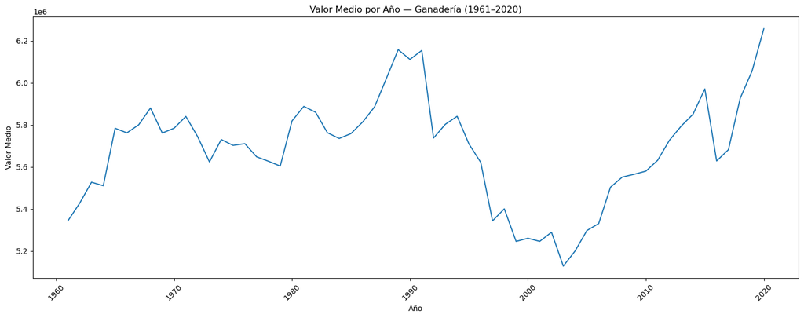

```python
# Valor medio por año
df_live1a['Year_int'] = df_live1a['Year'].dt.year
prod_live_año = df_live1a.groupby('Year_int')['Valor'].mean().reset_index()

plt.figure(figsize=(15, 6))
sns.lineplot(data=prod_live_año, x='Year_int', y='Valor')
plt.title('Valor Medio por Año — Ganadería (1961–2020)')
plt.xlabel('Año')
plt.ylabel('Valor Medio')
plt.xticks(rotation=45)
plt.tight_layout()
plt.show()
```

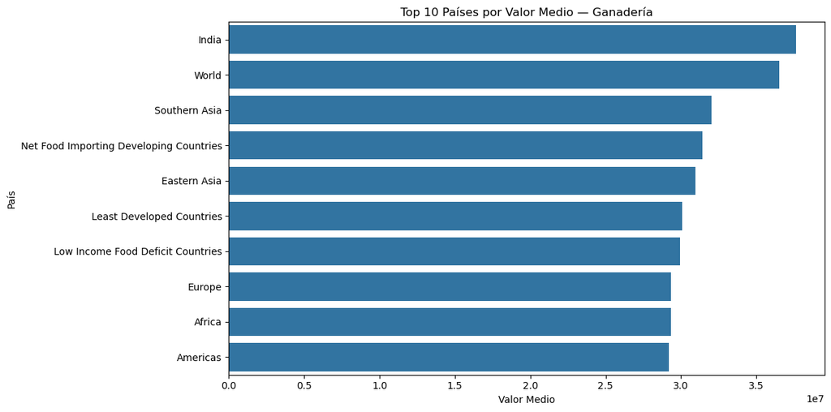

```python
# Top 10 países por valor medio
top_paises_live = df_live1a.groupby('País')['Valor'].mean().sort_values(ascending=False).head(10)

plt.figure(figsize=(12, 6))
sns.barplot(x=top_paises_live.values, y=top_paises_live.index)
plt.title('Top 10 Países por Valor Medio — Ganadería')
plt.xlabel('Valor Medio')
plt.ylabel('País')
plt.tight_layout()
plt.show()
```

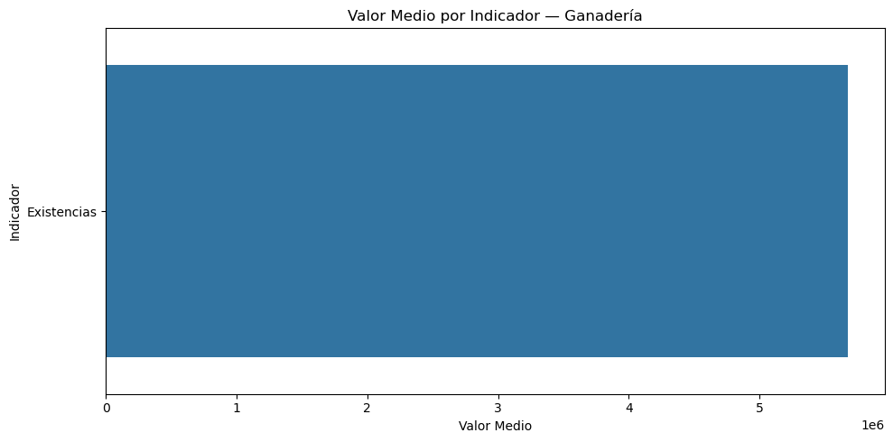

```python
# Valor medio por indicador
por_indicador_live = df_live1a.groupby('Indicador')['Valor'].mean().sort_values(ascending=False)

plt.figure(figsize=(10, 5))
sns.barplot(x=por_indicador_live.values, y=por_indicador_live.index)
plt.title('Valor Medio por Indicador — Ganadería')
plt.xlabel('Valor Medio')
plt.ylabel('Indicador')
plt.tight_layout()
plt.show()
```

# Resumen Final del Proceso de Limpieza

| Paso | crop1.csv | live1.csv |
| --- | --- | --- |
| Carga de datos | ✅ | ✅ |
| Exploración inicial (head, info) | ✅ | ✅ |
| Conteo de nulos | ✅ 129.500 nulos en Value | ✅ 2.264 nulos en Value |
| Eliminación de nulos | ✅ dropna | ✅ dropna |
| Verificación post-limpieza | ✅ | ✅ |
| Eliminación de duplicados | ✅ | ✅ |
| Copia de trabajo | ✅ df_crop1 | ✅ df_live1 |
| Corrección de tipos (Year, Value) | ✅ | ✅ |
| Limpieza de espacios en texto | ✅ | ✅ |
| Eliminación de valores negativos | ✅ | ✅ |
| Eliminación de outliers (p99) | ✅ | ✅ |
| Renombrado de columnas al español | ✅ | ✅ |
| Separación en dos DataFrames | ✅ df_crop1a / df_crop1b | ✅ df_live1a / df_live1b |
| Visualizaciones | ✅ 3 gráficas | ✅ 3 gráficas |

## ✅ Sistema de Limpieza de Datos — Oportunidad de Mejora: *DataCleanSystem*

- Importing the required libraries and reading the dataset.
- Preliminary exploration
- Check for the outliers and remove outliers.
- Dropping of redundant feature columns
- Missing value handling
- Regularizing the categorical columns
- Save the cleaned data